# Bayesian regularization methods for multifactor models

Taking a look at the multifactor models for the cross section of stock returns, such as the Fama-French 3 factor, Carhart 4 factor or APT models, we can try to evaluate the usefulness of each covariate in predicting stock returns. Nowadays, financial institutions might dispose of dozens, even hundreds of possible covariates for predicting returns. A linear model with too many variables, however, might lead to spurious relationships and/or overfitting. This is the problem known in machine learning as "feature selection".

Regularization methods are a way of solving this. Methods such as LASSO or ridge regression add a penalty to the regression function, "shrinking" coefficients towards zero. The purpose of this is so that more coefficients will equal zero, and less covariates will be deemed useful in predicting future observations.

We already went through the fact that, in Bayesian inference, regularization can be imposed via prior distributions. This comes handy in the estimation of Bayesian factor models, especially with many covariates.

In an article from 2015, Fama and French augment their traditional 3 factor model with two additional factors: profitability and investment. The "profitability" factor (RMW) stands for the premium for companies with robust profit margins minus weak profit margins. The "investment" factor (CMA) refers to companies' investment strategies regarding assets, and captures the premium for investing in companies with conservative investing minus aggressive ones.

We also include Carhart's momentum factor (MOM) and two factors proposed by researchers at AQR Capital Management, BAB and QMJ. Quality minus junk (QMJ), as presented by Asness, Frazzini and Pedersen, seeks to quantify the premium for investing in stocks with better quality measures, such as profitability, growth and safety, versus worse ("junk") ones.

Betting against beta (BAB), presented by Frazzini and Pedersen, is based on a real-world deviation from CAPM predictions. The CAPM predicts that investors will divide their wealth between the risk-free rate and the market portfolio, and their risk preferences will dictate how much they will allocate between both, or even borrow at the risk-free rate to leverage themselves at the market portfolio, for risk-loving agents. In reality, there is a restriction to how much agents can borrow and leverage themselves, so risk-lovers who want more leverage end up buying assets with high market beta, which makes assets with low market betas cheaper. The BAB factor captures the premium for investing in low market beta assets, therefore "betting against beta".

Frazzini, Kabiller and Pedersen (https://www.tandfonline.com/doi/full/10.2469/faj.v74.n4.3) find that including QMJ and BAB as additional factors in the traditional 4 factor (market, SMB, HML and momentum) model reduces the annualized alpha obtained by Berkshire Hathaway from 5.3% to 0.3% for the period between 1976 and 2011. See https://www8.gsb.columbia.edu/valueinvesting/sites/valueinvesting/files/14%20-%20Summary%20of%20%20%27Buffett%27s%20Alpha%27.pdf for a summary

As for macroeconomic variables, we include CPI inflation (12-month), industrial capacity utilization, GDP growth, returns on 3 month T-bill rates, the term spread (10 year minus 3 month Treasury rates) and the economic policy uncertainty index by Baker, Bloom and Davis (https://www.policyuncertainty.com/index.html). We use the three component index and scale it dividing the values by 100.

Our variables shall have daily frequency. We shall use linear interpolation to convert variables that do not have daily frequency. All variables that are percentages are quoted in absolute values e.g. an inflation of 2% appears as 2 and not as 0.02.

```python
import numpy as np
import pandas as pd
import matplotlib.pyplot as plt
import yfinance as yf
import pymc as pm
import arviz as az
%matplotlib inline
```

[output not shown]

```python
ff5f = pd.read_csv("https://mba.tuck.dartmouth.edu/pages/faculty/ken.french/ftp/F-F_Research_Data_5_Factors_2x3_daily_CSV.zip", skiprows=2, index_col=0)
ff5f.index = pd.to_datetime(ff5f.index, format="%Y%m%d")
ff5f.tail()
```

|  | Mkt-RF | SMB | HML | RMW | CMA | RF |
| --- | --- | --- | --- | --- | --- | --- |
| 2022-06-24 | 3.11 | -0.40 | -0.05 | 0.08 | -0.34 | 0.003 |
| 2022-06-27 | -0.28 | 0.75 | 1.24 | -0.30 | 1.29 | 0.003 |
| 2022-06-28 | -2.10 | 0.05 | 2.36 | -0.70 | 1.28 | 0.003 |
| 2022-06-29 | -0.20 | -0.58 | -1.30 | 1.06 | -0.83 | 0.003 |
| 2022-06-30 | -0.95 | 0.53 | -0.15 | 0.92 | -0.18 | 0.003 |

```python
mom = pd.read_csv("https://mba.tuck.dartmouth.edu/pages/faculty/ken.french/ftp/F-F_Momentum_Factor_daily_CSV.zip", skiprows=12, skipfooter=1, index_col=0, engine="python")
mom.index = pd.to_datetime(mom.index, format="%Y%m%d")
mom.columns = ["MOM"]

qmj = pd.read_excel("https://www.aqr.com/-/media/AQR/Documents/Insights/Data-Sets/Quality-Minus-Junk-Factors-Daily.xlsx", skiprows=18, index_col=0, usecols="A,Y") * 100
qmj.index = pd.to_datetime(qmj.index, format="%m/%d/%Y")
qmj.columns = ["QMJ"]

bab = pd.read_excel("https://www.aqr.com/-/media/AQR/Documents/Insights/Data-Sets/Betting-Against-Beta-Equity-Factors-Daily.xlsx", skiprows=18, index_col=0, usecols="A,Y") * 100
bab.index = pd.to_datetime(bab.index, format="%m/%d/%Y")
bab.columns = ["BAB"]
```

```python
cpi_infl = pd.read_csv("https://api.db.nomics.world/v22/series/BLS/cu/CUSR0000SA0.csv", index_col = 0).pct_change(periods=12)["2010-01-01":] * 100
cpi_infl.index = pd.to_datetime(cpi_infl.index, format="%Y-%m")
cpi_infl.columns = ["CPI inflation"]
cpi_infl = cpi_infl.asfreq("D").interpolate()

cap_util = pd.read_csv("https://api.db.nomics.world/v22/series/FED/G17_CAPUTL/CAPUTL.B50001.S.csv", index_col = 0).apply(np.log)
cap_util.index = pd.to_datetime(cap_util.index, format="%Y-%m-%d")
cap_util.columns = ["Capacity utilization"]
cap_util = cap_util.asfreq("D").interpolate()

gdp_growth = pd.read_csv("https://api.db.nomics.world/v22/series/BEA/GDPbyIndustry-15/II-Q.csv", index_col = 0).pct_change() * 100
gdp_growth.index = pd.PeriodIndex(gdp_growth.index, freq='Q').to_timestamp()
gdp_growth.columns = ["GDP growth"]
gdp_growth = gdp_growth.asfreq("D").interpolate()

irx = pd.DataFrame((yf.Ticker("^IRX").history(period="max")["Close"]).rename("3 month T-bill", inplace=True))

uncertainty = pd.read_excel("https://www.policyuncertainty.com/media/US_Policy_Uncertainty_Data.xlsx", skipfooter=1)
uncertainty['date'] = pd.to_datetime(uncertainty['Year'].astype(str) + "-" + uncertainty['Month'].astype(str), format="%Y-%m")
uncertainty.set_index('date', inplace=True)
uncertainty = pd.DataFrame(uncertainty["Three_Component_Index"])
uncertainty.columns = ["Uncertainty index"]
uncertainty = uncertainty.asfreq("D").interpolate() / 100

term_spread = pd.read_csv("https://www.ivo-welch.info/fredwrap?symbol=T10Y3M", index_col=0).apply(pd.to_numeric, errors='coerce').interpolate()
term_spread.index = pd.to_datetime(term_spread.index, format="%Y%m%d")
term_spread.columns = ["Term spread"]
term_spread = term_spread.asfreq("D").interpolate()
```

```
array([[<AxesSubplot:>, <AxesSubplot:>, <AxesSubplot:>, <AxesSubplot:>,
        <AxesSubplot:>],
       [<AxesSubplot:>, <AxesSubplot:>, <AxesSubplot:>, <AxesSubplot:>,
        <AxesSubplot:>],
       [<AxesSubplot:>, <AxesSubplot:>, <AxesSubplot:>, <AxesSubplot:>,
        <AxesSubplot:>]], dtype=object)
```

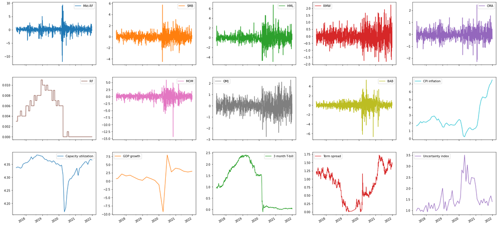

```python
start_date = "2017-06-01"
end_date = "2022-01-01"

factors = pd.concat([ff5f,mom,qmj,bab,cpi_infl,cap_util,gdp_growth,irx,term_spread,uncertainty], axis=1)
factors.index = pd.to_datetime(factors.index)
factors = factors[start_date:end_date].dropna()
factors.plot(subplots=True, layout=(3,5), figsize = (30,15))
```

We shall start with a simple linear model for the returns of JPMorgan's Ultra-Short Income ETF (JPST), one of the top actively managed ETFs in terms of market capitalization

```python
import statsmodels.api as sm

jpst = yf.Ticker("JPST").history(start = "2017-05-31", end = end_date)["Close"].rename("JPST", inplace=True).pct_change().dropna()*100
jpst = jpst - factors["RF"]

model = sm.OLS(jpst, sm.add_constant(factors.drop("RF", axis=1))) # add_constant so that our model has an intercept
results = model.fit()
print(results.summary())
```

```
                            OLS Regression Results
==============================================================================
Dep. Variable:                      y   R-squared:                       0.199
Model:                            OLS   Adj. R-squared:                  0.189
Method:                 Least Squares   F-statistic:                     20.21
Date:                Tue, 16 Aug 2022   Prob (F-statistic):           4.23e-46
Time:                        09:25:39   Log-Likelihood:                 1495.6
No. Observations:                1156   AIC:                            -2961.
Df Residuals:                    1141   BIC:                            -2885.
Df Model:                          14
Covariance Type:            nonrobust
========================================================================================
                           coef    std err          t      P>|t|      [0.025      0.975]
----------------------------------------------------------------------------------------
const                    1.5082      0.434      3.475      0.001       0.657       2.360
Mkt-RF                   0.0166      0.002      9.650      0.000       0.013       0.020
SMB                     -0.0028      0.003     -0.833      0.405      -0.010       0.004
HML                      0.0082      0.003      2.400      0.017       0.001       0.015
RMW                      0.0054      0.007      0.810      0.418      -0.008       0.018
CMA                      0.0076      0.006      1.230      0.219      -0.005       0.020
MOM                     -0.0039      0.003     -1.549      0.122      -0.009       0.001
QMJ                     -0.0028      0.006     -0.471      0.638      -0.014       0.009
BAB                      0.0275      0.003      9.758      0.000       0.022       0.033
CPI inflation            0.0035      0.002      1.666      0.096      -0.001       0.008
Capacity utilization    -0.3455      0.100     -3.443      0.001      -0.542      -0.149
GDP growth              -0.0006      0.001     -0.666      0.505      -0.002       0.001
3 month T-bill           0.0068      0.005      1.258      0.208      -0.004       0.017
Term spread             -0.0084      0.007     -1.168      0.243      -0.022       0.006
Uncertainty index       -0.0096      0.007     -1.353      0.176      -0.024       0.004
==============================================================================
Omnibus:                     1163.163   Durbin-Watson:                   1.879
Prob(Omnibus):                  0.000   Jarque-Bera (JB):           447782.753
Skew:                          -3.972   Prob(JB):                         0.00
Kurtosis:                      99.091   Cond. No.                     1.32e+03
==============================================================================

Notes:
[1] Standard Errors assume that the covariance matrix of the errors is correctly specified.
[2] The condition number is large, 1.32e+03. This might indicate that there are
strong multicollinearity or other numerical problems.
```

Apparently the BAB factor does a very good job of explaining JPST returns.

Let's try non-Bayesian regularization and feature selection techniques via scikit-learn. We'll start with a ridge regression:

```python
from sklearn import linear_model
reg = linear_model.Ridge(alpha=1000)
reg.fit(factors.drop("RF", axis=1),jpst)
reg.coef_.round(4)
```

```
array([ 0.0115, -0.0005,  0.0039,  0.0012,  0.0014, -0.    ,  0.0005,
        0.0109, -0.0012, -0.0002,  0.0002, -0.0001, -0.0011,  0.0006])
```

The parameter $\alpha$ controls the strength of our regularization. We set it to $\alpha = 1000$ as an example. The case where $\alpha = 0$ is the standard linear regression.

We can reproduce the example from scikit-learn's user guide (https://scikit-learn.org/stable/auto_examples/feature_selection/plot_select_from_model_diabetes.html#sphx-glr-auto-examples-feature-selection-plot-select-from-model-diabetes-py) and find feature importance via ridge cross-validation. We must also pay attention to the scale of our variables before interpreting the coefficients. First we take a loot at the standard deviation of the covariates.

```
<BarContainer object of 15 artists>
```

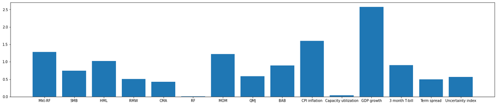

```python
plt.figure(figsize=(25,5))
plt.bar(height = factors.std(), x = factors.std().index)
```

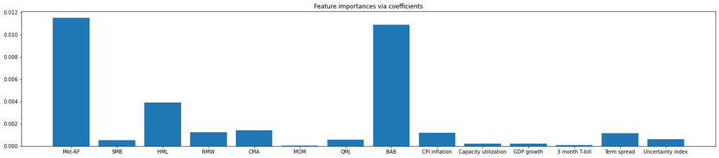

```python
from sklearn.linear_model import RidgeCV

ridge = RidgeCV(alphas=np.geomspace(1, 10000, num=5)).fit(factors.drop("RF", axis=1), jpst)
importance = np.abs(ridge.coef_)
feature_names = np.array(factors.drop("RF", axis=1).columns)
plt.figure(figsize=(25,5))
plt.bar(height=importance, x=feature_names)
plt.title("Feature importances via coefficients")
plt.show()
```

In this case, the market factor and BAB are the most important variables in explaining JPST returns throughout the period.

It turns out the ridge regression penalty can be imposed in the Bayesian framework. This would be equivalent to giving the regression coefficients a normal prior distribution. In this case, the standard deviation of the prior would control the strength of the regularization.

Let's try it out:

```python
coords = {"factor": factors.drop("RF", axis=1).columns}

with pm.Model(coords=coords) as bayes_ridge:
    alpha = pm.Normal("Intercept", mu=0, sigma=1e-3)
    beta = pm.Normal("Coefficients", mu=0, sigma=1e-3, dims="factor")

    y_mean = alpha + factors.drop("RF", axis=1).values * beta

    obs_noise = pm.HalfCauchy("sigma", beta=1)
    y = pm.Normal("likelihood", mu=y_mean, sigma=obs_noise, observed=jpst.values.reshape((-1,1)))
pm.model_to_graphviz(bayes_ridge)
```

[figure not shown]

```python
with bayes_ridge:
    trace_ridge = pm.sample(5000, tune=2000, return_inferencedata=True)
```

```
Auto-assigning NUTS sampler...
Initializing NUTS using jitter+adapt_diag...
Multiprocess sampling (4 chains in 4 jobs)
NUTS: [Intercept, Coefficients, sigma]
```

100.00% [28000/28000 01:06<00:00 Sampling 4 chains, 0 divergences]

```
Sampling 4 chains for 2_000 tune and 5_000 draw iterations (8_000 + 20_000 draws total) took 92 seconds.
```

```python
az.summary(trace_ridge)
```

|  | mean | sd | hdi_3% | hdi_97% | mcse_mean | mcse_sd | ess_bulk | ess_tail | r_hat |
| --- | --- | --- | --- | --- | --- | --- | --- | --- | --- |
| Intercept | 0.002 | 0.001 | 0.001 | 0.003 | 0.0 | 0.0 | 21241.0 | 16321.0 | 1.0 |
| Coefficients[Mkt-RF] | 0.005 | 0.001 | 0.003 | 0.006 | 0.0 | 0.0 | 25844.0 | 15428.0 | 1.0 |
| Coefficients[SMB] | 0.000 | 0.001 | -0.002 | 0.002 | 0.0 | 0.0 | 23660.0 | 15748.0 | 1.0 |
| Coefficients[HML] | 0.001 | 0.001 | -0.001 | 0.003 | 0.0 | 0.0 | 26834.0 | 14996.0 | 1.0 |
| Coefficients[RMW] | 0.000 | 0.001 | -0.002 | 0.002 | 0.0 | 0.0 | 26452.0 | 15423.0 | 1.0 |
| Coefficients[CMA] | 0.000 | 0.001 | -0.002 | 0.002 | 0.0 | 0.0 | 25718.0 | 15145.0 | 1.0 |
| Coefficients[MOM] | 0.000 | 0.001 | -0.001 | 0.002 | 0.0 | 0.0 | 22562.0 | 15125.0 | 1.0 |
| Coefficients[QMJ] | -0.000 | 0.001 | -0.002 | 0.002 | 0.0 | 0.0 | 28231.0 | 15242.0 | 1.0 |
| Coefficients[BAB] | 0.003 | 0.001 | 0.001 | 0.005 | 0.0 | 0.0 | 25837.0 | 15074.0 | 1.0 |
| Coefficients[CPI inflation] | -0.000 | 0.001 | -0.001 | 0.001 | 0.0 | 0.0 | 25917.0 | 16051.0 | 1.0 |
| Coefficients[Capacity utilization] | 0.000 | 0.000 | -0.001 | 0.001 | 0.0 | 0.0 | 24669.0 | 16722.0 | 1.0 |
| Coefficients[GDP growth] | 0.000 | 0.001 | -0.001 | 0.001 | 0.0 | 0.0 | 26181.0 | 14871.0 | 1.0 |
| Coefficients[3 month T-bill] | 0.000 | 0.001 | -0.001 | 0.002 | 0.0 | 0.0 | 23905.0 | 14910.0 | 1.0 |
| Coefficients[Term spread] | -0.000 | 0.001 | -0.002 | 0.002 | 0.0 | 0.0 | 25906.0 | 14959.0 | 1.0 |
| Coefficients[Uncertainty index] | 0.000 | 0.001 | -0.001 | 0.002 | 0.0 | 0.0 | 25445.0 | 15382.0 | 1.0 |
| sigma | 0.074 | 0.000 | 0.073 | 0.075 | 0.0 | 0.0 | 24488.0 | 14951.0 | 1.0 |

Other than imposing the ridge or LASSO via coefficient priors, we have other Bayesian regularization options.

The spike and slab regression is a common Bayesian variable selection technique. Spike and slab priors can be expressed as a mixture of a discrete distribution that will assign zero to some coefficients (the spike) and a continuous distribution with a larger variance (the slab), which would not be much restrictive of the values the non-zero coefficients can assume.

The spike and slab can be written as a mixture of normal distributions. The strength of the regularization can be controlled through the hyperparameters for the spike and the slab components.

An example of regression model with a spike and slab prior for $p= 1, \ldots, P$ possible covariates could be written as

$\pi \sim Beta(2,4)$,

$\gamma_p \sim Ber(\pi)$,

$\sigma_{feature} \sim HalfCauchy(1)$,

$\beta_r \sim N(0, \sigma^2_{feature})$,

$\beta_s \sim N(0, 0.000001)$,

$\beta_p = \gamma_p \beta_{r} + (1-\gamma_p) \beta_{s} $,

$\alpha \sim N(0, 1)$,

$\sigma_{obs} \sim HalfCauchy(b)$,

$Y_i \sim N(\alpha + (\gamma_p'\beta_p)' X_i, \sigma^2_{obs})$.

As the Bernoulli distribution is discrete, it cannot be sampled via NUTS algorithm. PyMC then uses the Metropolis algorithm, which is slower and may require more burn-in steps for tuning.

```python
coords = {"factor": factors.drop("RF", axis=1).columns}

with pm.Model(coords=coords) as ss_model:

    pi = pm.Beta("pi", 2, 4)
    gamma = pm.Bernoulli("gamma", p=pi, dims="factor")
    sd_feature = pm.HalfCauchy("sd_feature", 1)
    mix_sd = pm.math.switch(gamma > 0.5, sd_feature, 1e-3)

    beta = pm.Normal("Coefficients", mu=0, sigma=mix_sd, dims="factor")
    alpha = pm.Normal("Intercept", mu=0, sigma=1)
    y_mean = alpha + beta * factors.drop("RF", axis=1).values

    obs_noise = pm.HalfCauchy("sigma_obs", beta=1)
    y = pm.Normal("likelihood", mu=y_mean, sigma=obs_noise, observed=jpst.values.reshape((-1,1)))
pm.model_to_graphviz(ss_model)
```

[figure not shown]

```python
with ss_model:
    trace_ss = pm.sample(5000, tune=2000, target_accept=0.95, return_inferencedata=True)
```

```
Multiprocess sampling (4 chains in 4 jobs)
CompoundStep
>NUTS: [pi, sd_feature, Coefficients, Intercept, sigma_obs]
>BinaryGibbsMetropolis: [gamma]
```

100.00% [28000/28000 03:53<00:00 Sampling 4 chains, 0 divergences]

```
Sampling 4 chains for 2_000 tune and 5_000 draw iterations (8_000 + 20_000 draws total) took 260 seconds.
```

```
array([[<AxesSubplot:title={'center':'gamma'}>,
        <AxesSubplot:title={'center':'gamma'}>],
       [<AxesSubplot:title={'center':'Coefficients'}>,
        <AxesSubplot:title={'center':'Coefficients'}>],
       [<AxesSubplot:title={'center':'Intercept'}>,
        <AxesSubplot:title={'center':'Intercept'}>],
       [<AxesSubplot:title={'center':'pi'}>,
        <AxesSubplot:title={'center':'pi'}>],
       [<AxesSubplot:title={'center':'sd_feature'}>,
        <AxesSubplot:title={'center':'sd_feature'}>],
       [<AxesSubplot:title={'center':'sigma_obs'}>,
        <AxesSubplot:title={'center':'sigma_obs'}>]], dtype=object)
```

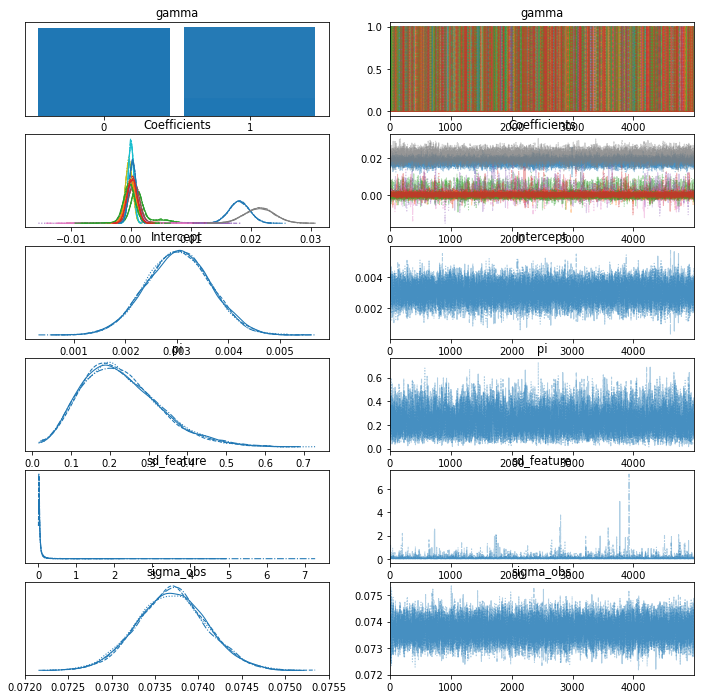

```python
az.plot_trace(trace_ss)
```

Another type of prior distribution well-suited for shrinkage and variable selection are global-local priors. These priors consist of two components: one global, that shrinks all coefficients towards zero, and one local for each covariate, that will allow the largest coefficients to escape zero.

One famous example of global-local prior is the horseshoe prior. The original horseshoe prior (http://proceedings.mlr.press/v5/carvalho09a/carvalho09a.pdf) is a mixture of two half-Cauchy distributions for each local plus the global components.

Another version deemed regularized horseshoe (https://arxiv.org/pdf/1707.01694.pdf) combine elements of the original horseshoe and the spike and slab. The regularized horseshoe imposes regularization on both small and large coefficients. As the regularized horseshoe is relatively new, the best ways to implement it are current subject of research, and NUTS sampling can result in some divergent transitions (https://discourse.mc-stan.org/t/divergent-transitions-with-the-horseshoe-prior/1651/2).

A model with the original horseshoe prior for $p = 1, \ldots, P$ possible covariates can look like

$\tau_0 = \frac{p_0}{P-p_0}\sigma_{obs}$,

$\tau \sim HalfNormal(\tau_0^2)$,

$\lambda_p \sim HalfCauchy(1)$,

$\beta_p \sim N(0, \lambda_p^2 \tau^2)$,

$\alpha \sim N(0, 1)$,

$Y_i \sim N(\alpha + \beta_p' X_i, \sigma^2_{obs})$,

There are many techniques for the global shrinkage parameter $\tau$. We follow Piironen and Vehtari (2017) in specifying it as a function of $\tau_0$, and then use $\tau_0$ as the standard deviation of a half-normal prior.

```python
coords = {"factor": factors.drop("RF", axis=1).columns}

with pm.Model(coords=coords) as hs_model:

    obs_noise = 0.01
    p0 = 7
    D = len(factors.drop("RF", axis=1).columns)
    tau0 = (p0/(D-p0))*obs_noise

    tau = pm.HalfNormal("tau", sigma=tau0)
    lamb = pm.HalfCauchy('lambda', 1/(factors.drop("RF", axis=1).std().values), dims="factor")

    z = pm.Normal('z', 0, 1, dims="factor")
    beta = pm.Deterministic("Coefficients", pm.math.dot(tau,lamb) * z, dims="factor")
    alpha = pm.Normal("Intercept", mu=0, sigma=1)

    y_mean = alpha + beta * factors.drop("RF", axis=1).values

    obs_noise = pm.HalfCauchy("sigma_obs", beta=0.1)
    y = pm.Normal("likelihood", mu=y_mean, sigma=obs_noise, observed=jpst.values.reshape((-1,1)))
pm.model_to_graphviz(hs_model)
```

[figure not shown]

```python
with hs_model:
    trace_hs = pm.sample(5000, tune=3000, target_accept=0.95, return_inferencedata=True)
```

```
Auto-assigning NUTS sampler...
Initializing NUTS using jitter+adapt_diag...
Multiprocess sampling (4 chains in 4 jobs)
NUTS: [tau, lambda, z, Intercept, sigma_obs]
```

100.00% [32000/32000 15:03<00:00 Sampling 4 chains, 1,448 divergences]

```
Sampling 4 chains for 3_000 tune and 5_000 draw iterations (12_000 + 20_000 draws total) took 931 seconds.
There were 504 divergences after tuning. Increase `target_accept` or reparameterize.
The acceptance probability does not match the target. It is 0.9051, but should be close to 0.95. Try to increase the number of tuning steps.
There were 330 divergences after tuning. Increase `target_accept` or reparameterize.
There were 383 divergences after tuning. Increase `target_accept` or reparameterize.
There were 231 divergences after tuning. Increase `target_accept` or reparameterize.
```

```
array([[<AxesSubplot:title={'center':'Intercept'}>,
        <AxesSubplot:title={'center':'Intercept'}>],
       [<AxesSubplot:title={'center':'tau'}>,
        <AxesSubplot:title={'center':'tau'}>],
       [<AxesSubplot:title={'center':'lambda'}>,
        <AxesSubplot:title={'center':'lambda'}>],
       [<AxesSubplot:title={'center':'sigma_obs'}>,
        <AxesSubplot:title={'center':'sigma_obs'}>],
       [<AxesSubplot:title={'center':'Coefficients'}>,
        <AxesSubplot:title={'center':'Coefficients'}>]], dtype=object)
```

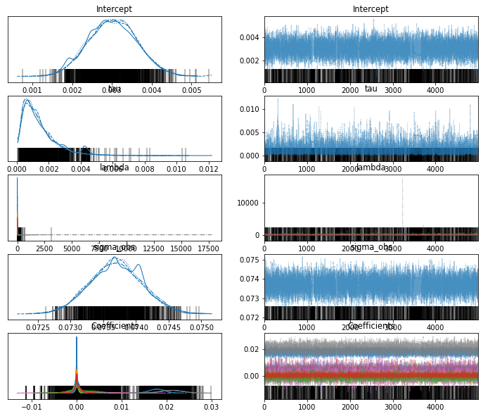

```python
az.plot_trace(trace_hs, var_names=['~z'])
```

```python
az.summary(trace_hs, var_names=["~z"])
```

|  | mean | sd | hdi_3% | hdi_97% | mcse_mean | mcse_sd | ess_bulk | ess_tail | r_hat |
| --- | --- | --- | --- | --- | --- | --- | --- | --- | --- |
| Intercept | 0.003 | 0.001 | 0.002 | 0.004 | 0.000 | 0.000 | 6606.0 | 3190.0 | 1.0 |
| tau | 0.001 | 0.001 | 0.000 | 0.003 | 0.000 | 0.000 | 2226.0 | 588.0 | 1.0 |
| lambda[Mkt-RF] | 28.267 | 53.066 | 1.160 | 80.826 | 0.618 | 0.437 | 5007.0 | 8682.0 | 1.0 |
| lambda[SMB] | 1.736 | 3.225 | 0.000 | 5.051 | 0.029 | 0.021 | 11267.0 | 8625.0 | 1.0 |
| lambda[HML] | 3.337 | 7.319 | 0.000 | 10.109 | 0.067 | 0.047 | 7258.0 | 7344.0 | 1.0 |
| lambda[RMW] | 3.056 | 6.963 | 0.000 | 8.840 | 0.099 | 0.070 | 3590.0 | 2689.0 | 1.0 |
| lambda[CMA] | 3.524 | 8.750 | 0.000 | 10.208 | 0.088 | 0.062 | 3859.0 | 7811.0 | 1.0 |
| lambda[MOM] | 1.566 | 7.906 | 0.000 | 3.814 | 0.307 | 0.225 | 1970.0 | 463.0 | 1.0 |
| lambda[QMJ] | 2.390 | 5.879 | 0.000 | 7.033 | 0.102 | 0.072 | 3034.0 | 526.0 | 1.0 |
| lambda[BAB] | 35.332 | 144.176 | 1.267 | 99.443 | 1.366 | 0.966 | 1992.0 | 539.0 | 1.0 |
| lambda[CPI inflation] | 0.699 | 1.403 | 0.000 | 1.985 | 0.014 | 0.012 | 10908.0 | 8226.0 | 1.0 |
| lambda[Capacity utilization] | 7.171 | 15.198 | 0.000 | 23.837 | 0.541 | 0.454 | 1890.0 | 2558.0 | 1.0 |
| lambda[GDP growth] | 0.569 | 1.792 | 0.000 | 1.520 | 0.051 | 0.041 | 7772.0 | 6528.0 | 1.0 |
| lambda[3 month T-bill] | 1.259 | 2.262 | 0.000 | 3.649 | 0.024 | 0.017 | 7158.0 | 6118.0 | 1.0 |
| lambda[Term spread] | 2.301 | 4.786 | 0.000 | 6.402 | 0.049 | 0.039 | 9774.0 | 8906.0 | 1.0 |
| lambda[Uncertainty index] | 1.613 | 2.658 | 0.000 | 4.793 | 0.023 | 0.016 | 9711.0 | 7839.0 | 1.0 |
| sigma_obs | 0.074 | 0.000 | 0.073 | 0.074 | 0.000 | 0.000 | 10284.0 | 11707.0 | 1.0 |
| Coefficients[Mkt-RF] | 0.018 | 0.002 | 0.015 | 0.021 | 0.000 | 0.000 | 17618.0 | 13552.0 | 1.0 |
| Coefficients[SMB] | 0.000 | 0.001 | -0.003 | 0.003 | 0.000 | 0.000 | 6889.0 | 9041.0 | 1.0 |
| Coefficients[HML] | 0.002 | 0.002 | -0.001 | 0.007 | 0.000 | 0.000 | 1881.0 | 580.0 | 1.0 |
| Coefficients[RMW] | 0.001 | 0.002 | -0.003 | 0.006 | 0.000 | 0.000 | 7273.0 | 9972.0 | 1.0 |
| Coefficients[CMA] | 0.001 | 0.003 | -0.004 | 0.007 | 0.000 | 0.000 | 7151.0 | 8253.0 | 1.0 |
| Coefficients[MOM] | 0.001 | 0.001 | -0.001 | 0.003 | 0.000 | 0.000 | 10643.0 | 13312.0 | 1.0 |
| Coefficients[QMJ] | -0.000 | 0.002 | -0.004 | 0.004 | 0.000 | 0.000 | 4955.0 | 3140.0 | 1.0 |
| Coefficients[BAB] | 0.021 | 0.002 | 0.016 | 0.025 | 0.000 | 0.000 | 10518.0 | 7750.0 | 1.0 |
| Coefficients[CPI inflation] | -0.000 | 0.000 | -0.001 | 0.001 | 0.000 | 0.000 | 10016.0 | 4924.0 | 1.0 |
| Coefficients[Capacity utilization] | 0.000 | 0.000 | -0.001 | 0.001 | 0.000 | 0.000 | 14936.0 | 15821.0 | 1.0 |
| Coefficients[GDP growth] | 0.000 | 0.000 | -0.001 | 0.001 | 0.000 | 0.000 | 6090.0 | 4469.0 | 1.0 |
| Coefficients[3 month T-bill] | -0.000 | 0.001 | -0.002 | 0.002 | 0.000 | 0.000 | 7576.0 | 5025.0 | 1.0 |
| Coefficients[Term spread] | -0.001 | 0.002 | -0.004 | 0.002 | 0.000 | 0.000 | 2617.0 | 777.0 | 1.0 |
| Coefficients[Uncertainty index] | 0.000 | 0.001 | -0.002 | 0.002 | 0.000 | 0.000 | 7576.0 | 10604.0 | 1.0 |

The regularized horseshoe model from Piironen and Vehtari (2017) differs from the original horseshoe in that it adds an additional shrinkage component $c^2$, to which the authors assign an inverse gamma distribution.

We specify the following model with the regularized horseshoe

$\tau_0 = \frac{p_0}{P-p_0}\sigma_{obs}$,

$\tau \sim HalfNormal(\tau_0^2)$,

$\lambda_p \sim HalfCauchy(1)$,

$c^2 \sim InvGamma(\frac{\nu}{2}, \frac{\nu s}{2})$

$\xi_p^2 = \frac{c^2 \lambda_p^2}{c^2 + \tau^2 \lambda_p^2}$,

$\beta_p \sim N(0, \tau^2 \xi^2)$,

$\alpha \sim N(0, 1)$,

$Y_i \sim N(\alpha + \beta_p' X_i, \sigma^2_{obs})$,

where $\nu$ and $s$ are, respectively, the degrees of freedom and scale parameters of a scaled inverse chi-squared distribution, here parametrized as the equivalent inverse gamma distribution.

```python
coords = {"factor": factors.drop("RF", axis=1).columns}

with pm.Model(coords=coords) as reg_hs_model:

    obs_noise = 0.01
    p0 = 7
    D = len(factors.drop("RF", axis=1).columns)
    tau0 = (p0/(D-p0))*obs_noise

    tau = pm.HalfNormal("tau", sigma=tau0)
    lamb = pm.HalfCauchy('lambda', 1/(factors.drop("RF", axis=1).std().values), dims="factor")

    c_df = 4
    c_scale = 1
    c_sq = pm.InverseGamma("c_sq", c_df * 0.5, c_df * c_scale * 0.5)
    c = pm.math.sqrt(c_sq)
    xi = (pm.math.dot(c,lamb)/(c + pm.math.dot(tau, lamb)))

    z = pm.Normal('z', 0, 1, dims="factor")
    beta = pm.Deterministic("Coefficients", pm.math.dot(tau,xi) * z, dims="factor")
    alpha = pm.Normal("Intercept", mu=0, sigma=1)

    y_mean = alpha + beta * factors.drop("RF", axis=1).values

    y = pm.Normal("likelihood", mu=y_mean, sigma=obs_noise, observed=jpst.values.reshape((-1,1)))
pm.model_to_graphviz(reg_hs_model)
```

[figure not shown]

```python
with reg_hs_model:
    trace_rhs = pm.sample(5000, tune=5000, target_accept=0.95, return_inferencedata=True)
```

```
Auto-assigning NUTS sampler...
Initializing NUTS using jitter+adapt_diag...
Multiprocess sampling (4 chains in 4 jobs)
NUTS: [tau, lambda, c_sq, z, Intercept]
```

100.00% [40000/40000 2:06:27<00:00 Sampling 4 chains, 1,769 divergences]

```
Sampling 4 chains for 5_000 tune and 5_000 draw iterations (20_000 + 20_000 draws total) took 7612 seconds.
There were 526 divergences after tuning. Increase `target_accept` or reparameterize.
There were 413 divergences after tuning. Increase `target_accept` or reparameterize.
There were 426 divergences after tuning. Increase `target_accept` or reparameterize.
There were 404 divergences after tuning. Increase `target_accept` or reparameterize.
```

```
array([[<AxesSubplot:title={'center':'Intercept'}>,
        <AxesSubplot:title={'center':'Intercept'}>],
       [<AxesSubplot:title={'center':'tau'}>,
        <AxesSubplot:title={'center':'tau'}>],
       [<AxesSubplot:title={'center':'lambda'}>,
        <AxesSubplot:title={'center':'lambda'}>],
       [<AxesSubplot:title={'center':'c_sq'}>,
        <AxesSubplot:title={'center':'c_sq'}>],
       [<AxesSubplot:title={'center':'Coefficients'}>,
        <AxesSubplot:title={'center':'Coefficients'}>]], dtype=object)
```

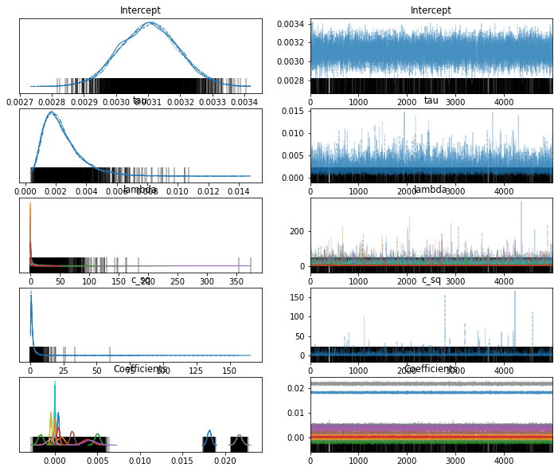

```python
az.plot_trace(trace_rhs, var_names=['~z'])
```

```python
with pm.Model(coords=coords) as bayes_flat:
    alpha = pm.Normal("Intercept", mu=0, sigma=1e4)
    beta = pm.Normal("Coefficients", mu=0, sigma=1e4, dims="factor")

    y_mean = alpha + factors.drop("RF", axis=1).values * beta

    obs_noise = pm.HalfCauchy("sigma", beta=1)
    y = pm.Normal("likelihood", mu=y_mean, sigma=obs_noise, observed=jpst.values.reshape((-1,1)))
    trace_flat = pm.sample(5000, tune=2000, return_inferencedata=True)
```

```
Auto-assigning NUTS sampler...
Initializing NUTS using jitter+adapt_diag...
Multiprocess sampling (4 chains in 4 jobs)
NUTS: [Intercept, Coefficients, sigma]
```

100.00% [28000/28000 00:44<00:00 Sampling 4 chains, 0 divergences]

```
Sampling 4 chains for 2_000 tune and 5_000 draw iterations (8_000 + 20_000 draws total) took 76 seconds.
```

```
array([<AxesSubplot:title={'center':'95.0% HDI'}>], dtype=object)
```

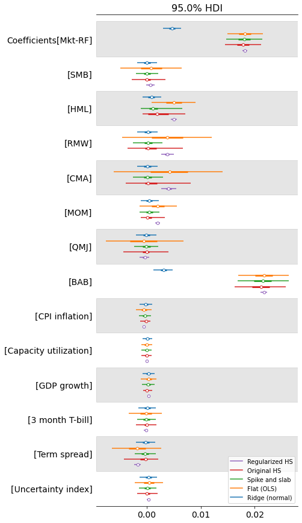

```python
az.plot_forest([trace_ridge, trace_flat, trace_ss, trace_hs, trace_rhs], model_names = ["Ridge (normal)", "Flat (OLS)", "Spike and slab", "Original HS", "Regularized HS"], var_names=["Coefficients"], combined=True, hdi_prob=0.95)
```